# Time dependent Cox: sensitivity analysis in patients aged 65 and above

**Age of entry**

```r
cox1 <- coxph(Surv(time1, time2, event_death) ~ age_entry, data = all_df)

summary(cox1)
```

```
## Call:
## coxph(formula = Surv(time1, time2, event_death) ~ age_entry,
##     data = all_df)
##
##   n= 56624, number of events= 5065
##
##               coef exp(coef) se(coef)     z Pr(>|z|)
## age_entry 0.076449  1.079447 0.002215 34.51   <2e-16 ***
## ---
## Signif. codes:  0 '***' 0.001 '**' 0.01 '*' 0.05 '.' 0.1 ' ' 1
##
##           exp(coef) exp(-coef) lower .95 upper .95
## age_entry     1.079     0.9264     1.075     1.084
##
## Concordance= 0.651  (se = 0.005 )
## Likelihood ratio test= 1256  on 1 df,   p=<2e-16
## Wald test            = 1191  on 1 df,   p=<2e-16
## Score (logrank) test = 1213  on 1 df,   p=<2e-16
```

```r
cox.zph(cox1)
```

```
##           chisq df     p
## age_entry  19.5  1 1e-05
## GLOBAL     19.5  1 1e-05
```

```
## [1] "Schoenfeld's test results for age of entry"
## [1] "Beta(t) for age of entry"
```

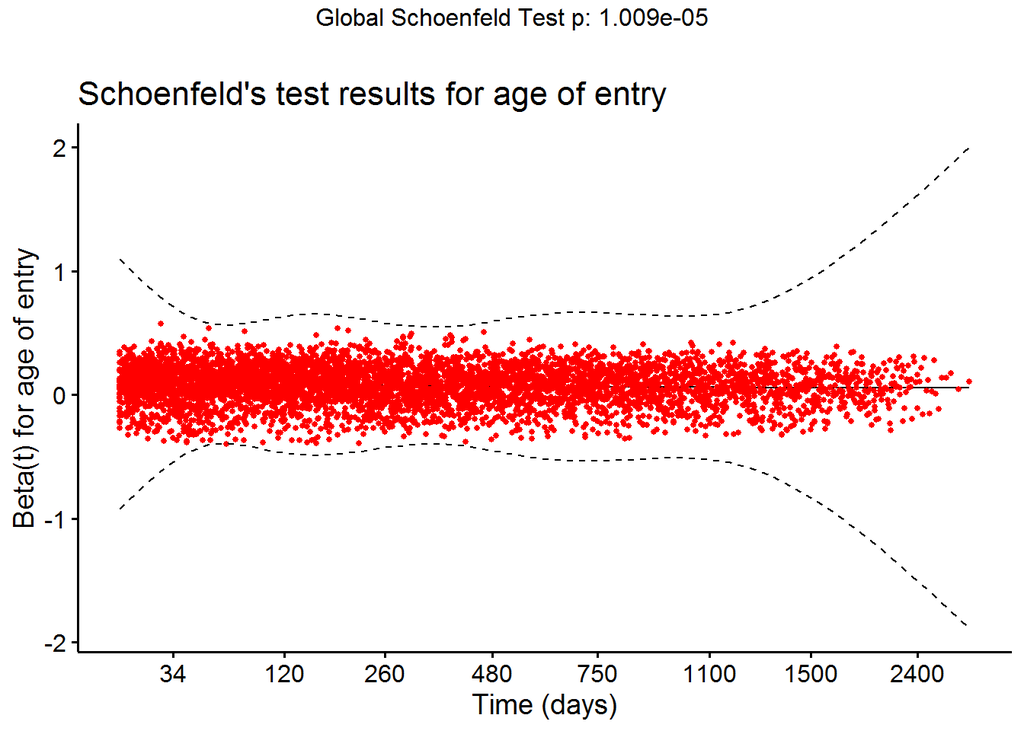

```r
res1 <- cox.zph(cox1)

plot_schoenfeld(res1, "age of entry")
```

```r
anova(cox1)
```

```
## Analysis of Deviance Table
##  Cox model: response is Surv(time1, time2, event_death)
## Terms added sequentially (first to last)
##
##           loglik  Chisq Df Pr(>|Chi|)
## NULL      -41451
## age_entry -40823 1255.5  1  < 2.2e-16 ***
## ---
## Signif. codes:  0 '***' 0.001 '**' 0.01 '*' 0.05 '.' 0.1 ' ' 1
```

**Age at observation**

```r
cox2 <- coxph(Surv(time1, time2, event_death) ~ age_obsv, data = all_df)

summary(cox2)
```

```
## Call:
## coxph(formula = Surv(time1, time2, event_death) ~ age_obsv, data = all_df)
##
##   n= 56624, number of events= 5065
##
##             coef exp(coef) se(coef)     z Pr(>|z|)
## age_obsv 0.08219   1.08566  0.00222 37.02   <2e-16 ***
## ---
## Signif. codes:  0 '***' 0.001 '**' 0.01 '*' 0.05 '.' 0.1 ' ' 1
##
##          exp(coef) exp(-coef) lower .95 upper .95
## age_obsv     1.086     0.9211     1.081      1.09
##
## Concordance= 0.655  (se = 0.005 )
## Likelihood ratio test= 1454  on 1 df,   p=<2e-16
## Wald test            = 1371  on 1 df,   p=<2e-16
## Score (logrank) test = 1399  on 1 df,   p=<2e-16
```

```r
cox.zph(cox2)
```

```
##          chisq df    p
## age_obsv  2.38  1 0.12
## GLOBAL    2.38  1 0.12
```

```
## [1] "Schoenfeld's test results for age at observation"
## [1] "Beta(t) for age at observation"
```

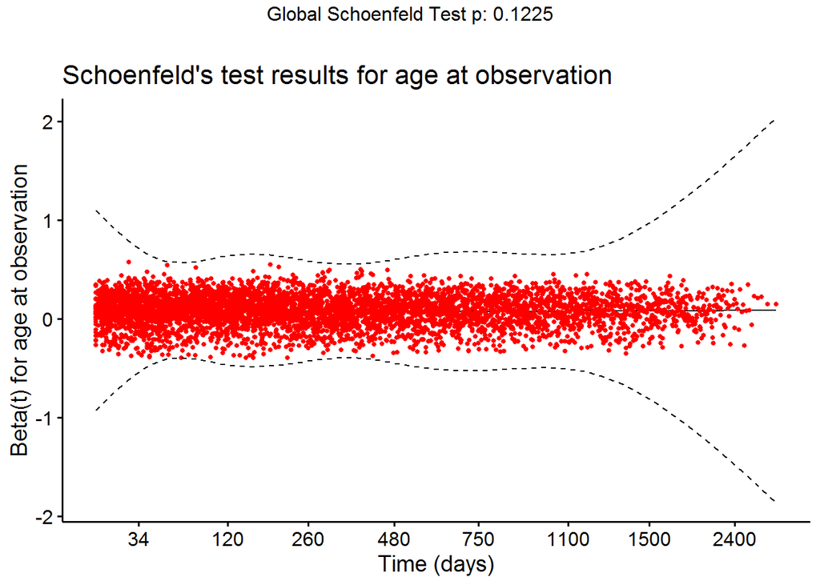

```r
res2 <- cox.zph(cox2)

plot_schoenfeld(res2, "age at observation")
```

```r
anova(cox2)
```

```
## Analysis of Deviance Table
##  Cox model: response is Surv(time1, time2, event_death)
## Terms added sequentially (first to last)
##
##          loglik  Chisq Df Pr(>|Chi|)
## NULL     -41451
## age_obsv -40724 1454.4  1  < 2.2e-16 ***
## ---
## Signif. codes:  0 '***' 0.001 '**' 0.01 '*' 0.05 '.' 0.1 ' ' 1
```

**Age of diagnosis**

```r
cox3 <- coxph(Surv(time1, time2, event_death) ~ age_diag, data = all_df)

summary(cox3)
```

```
## Call:
## coxph(formula = Surv(time1, time2, event_death) ~ age_diag, data = all_df)
##
##   n= 56624, number of events= 5065
##
##              coef exp(coef) se(coef)     z Pr(>|z|)
## age_diag 0.071096  1.073684 0.002163 32.87   <2e-16 ***
## ---
## Signif. codes:  0 '***' 0.001 '**' 0.01 '*' 0.05 '.' 0.1 ' ' 1
##
##          exp(coef) exp(-coef) lower .95 upper .95
## age_diag     1.074     0.9314     1.069     1.078
##
## Concordance= 0.645  (se = 0.005 )
## Likelihood ratio test= 1131  on 1 df,   p=<2e-16
## Wald test            = 1080  on 1 df,   p=<2e-16
## Score (logrank) test = 1099  on 1 df,   p=<2e-16
```

```r
cox.zph(cox3)
```

```
##          chisq df       p
## age_diag  28.5  1 9.5e-08
## GLOBAL    28.5  1 9.5e-08
```

```
## [1] "Schoenfeld's test results for age of diagnosis"
## [1] "Beta(t) for age of diagnosis"
```

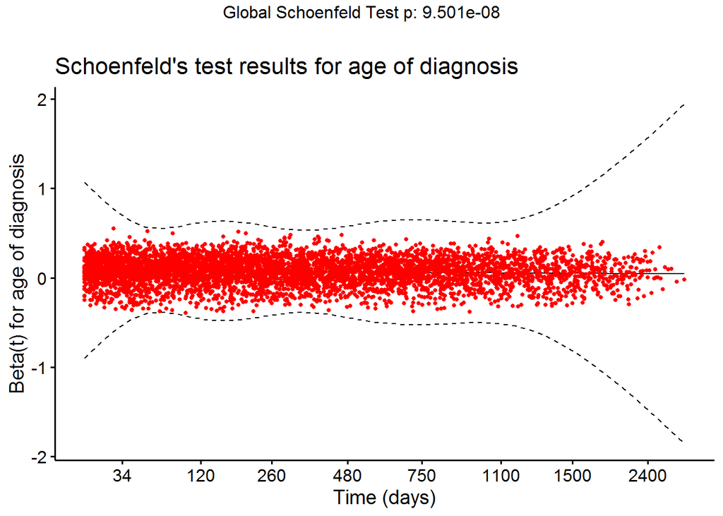

```r
res3 <- cox.zph(cox3)

plot_schoenfeld(res3, "age of diagnosis")
```

```r
anova(cox3)
```

```
## Analysis of Deviance Table
##  Cox model: response is Surv(time1, time2, event_death)
## Terms added sequentially (first to last)
##
##          loglik  Chisq Df Pr(>|Chi|)
## NULL     -41451
## age_diag -40885 1131.4  1  < 2.2e-16 ***
## ---
## Signif. codes:  0 '***' 0.001 '**' 0.01 '*' 0.05 '.' 0.1 ' ' 1
```

**Dementia medication exposure**

```r
table(all_df$med_exposure)
```

```
##
##   exposed unexposed
##     42951     13673
```

```r
cox4 <- coxph(Surv(time1, time2, event_death) ~ med_exposure, data = all_df)

summary(cox4)
```

```
## Call:
## coxph(formula = Surv(time1, time2, event_death) ~ med_exposure,
##     data = all_df)
##
##   n= 56624, number of events= 5065
##
##                          coef exp(coef) se(coef)     z Pr(>|z|)
## med_exposureunexposed 0.09963   1.10476  0.02941 3.388 0.000705 ***
## ---
## Signif. codes:  0 '***' 0.001 '**' 0.01 '*' 0.05 '.' 0.1 ' ' 1
##
##                       exp(coef) exp(-coef) lower .95 upper .95
## med_exposureunexposed     1.105     0.9052     1.043      1.17
##
## Concordance= 0.538  (se = 0.004 )
## Likelihood ratio test= 11.37  on 1 df,   p=7e-04
## Wald test            = 11.48  on 1 df,   p=7e-04
## Score (logrank) test = 11.49  on 1 df,   p=7e-04
```

```r
cox.zph(cox4)
```

```
##              chisq df      p
## med_exposure   171  1 <2e-16
## GLOBAL         171  1 <2e-16
```

```
## [1] "Schoenfeld's test results for dementia medication exposure"
## [1] "Beta(t) for dementia medication exposure"
```

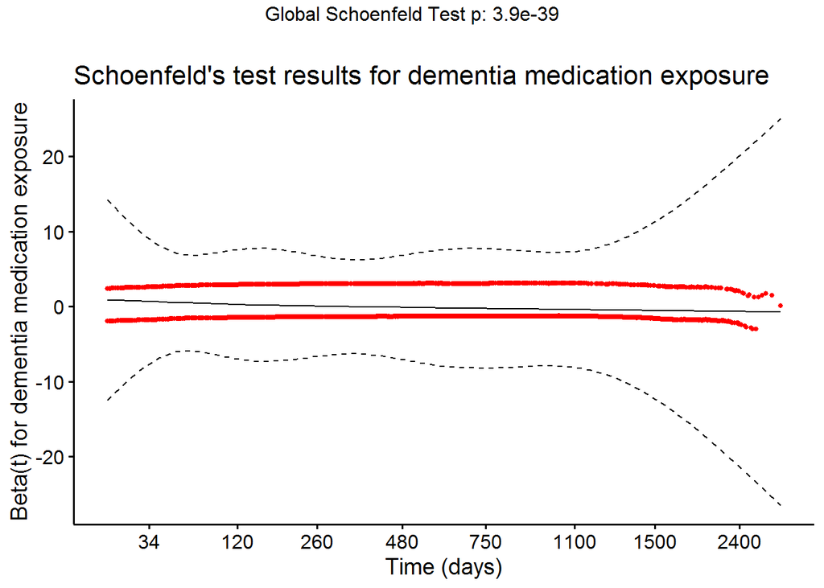

```r
res4 <- cox.zph(cox4)

plot_schoenfeld(res4, "dementia medication exposure")
```

```
## [1] "Survival probablity in OxNHS dementia patients: Age 65+"
## [1] "Adjusted for dementia medication exposure (time-dependent analysis)"
```

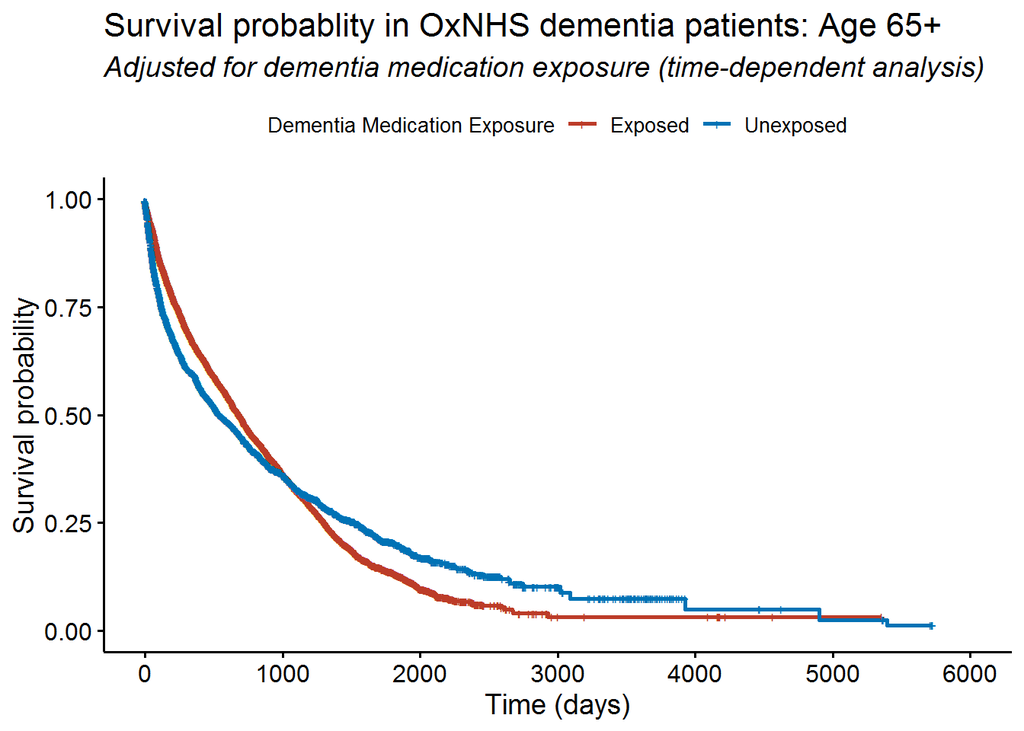

```r
fit4 <- survfit(Surv(time1, time2, event_death) ~ med_exposure, data = all_df)

plot_surv(fit4, "dementia medication exposure", c("Exposed", "Unexposed"))
```

```r
anova(cox4)
```

```
## Analysis of Deviance Table
##  Cox model: response is Surv(time1, time2, event_death)
## Terms added sequentially (first to last)
##
##              loglik  Chisq Df Pr(>|Chi|)
## NULL         -41451
## med_exposure -41445 11.369  1  0.0007467 ***
## ---
## Signif. codes:  0 '***' 0.001 '**' 0.01 '*' 0.05 '.' 0.1 ' ' 1
```

**Initial dementia diagnosis**

```r
freq_per_info(all_df$cause_diagper)
```

```
## var :
##             Frequency Percent Cum. percent
## Unspecified     32777    57.9         57.9
## AD              18455    32.6         90.5
## VaD              2808     5.0         95.4
## DLB              1498     2.6         98.1
## MixedADVaD        594     1.0         99.1
## FTD               370     0.7         99.8
## PPD               122     0.2        100.0
##   Total         56624   100.0        100.0
```

```r
cox5 <- coxph(Surv(time1, time2, event_death) ~ cause_diagper, data = all_df)

summary(cox5)
```

```
## Call:
## coxph(formula = Surv(time1, time2, event_death) ~ cause_diagper,
##     data = all_df)
##
##   n= 56624, number of events= 5065
##
##                              coef exp(coef) se(coef)      z Pr(>|z|)
## cause_diagperDLB          0.29608   1.34457  0.09587  3.088  0.00201 **
## cause_diagperFTD         -0.26489   0.76729  0.22505 -1.177  0.23918
## cause_diagperMixedADVaD   0.17881   1.19580  0.13842  1.292  0.19643
## cause_diagperPPD          0.48504   1.62425  0.28980  1.674  0.09419 .
## cause_diagperUnspecified  0.14120   1.15166  0.03120  4.525 6.04e-06 ***
## cause_diagperVaD          0.40587   1.50061  0.06100  6.653 2.87e-11 ***
## ---
## Signif. codes:  0 '***' 0.001 '**' 0.01 '*' 0.05 '.' 0.1 ' ' 1
##
##                          exp(coef) exp(-coef) lower .95 upper .95
## cause_diagperDLB            1.3446     0.7437    1.1142     1.623
## cause_diagperFTD            0.7673     1.3033    0.4936     1.193
## cause_diagperMixedADVaD     1.1958     0.8363    0.9117     1.568
## cause_diagperPPD            1.6242     0.6157    0.9204     2.866
## cause_diagperUnspecified    1.1517     0.8683    1.0833     1.224
## cause_diagperVaD            1.5006     0.6664    1.3315     1.691
##
## Concordance= 0.532  (se = 0.004 )
## Likelihood ratio test= 57.04  on 6 df,   p=2e-10
## Wald test            = 58.73  on 6 df,   p=8e-11
## Score (logrank) test = 59.18  on 6 df,   p=7e-11
```

```r
cox.zph(cox5)
```

```
##               chisq df       p
## cause_diagper  31.8  6 1.8e-05
## GLOBAL         31.8  6 1.8e-05
```

```
## [1] "Schoenfeld's test results for initial dementia diagnosis"
## [1] "Beta(t) for initial dementia diagnosis"
```

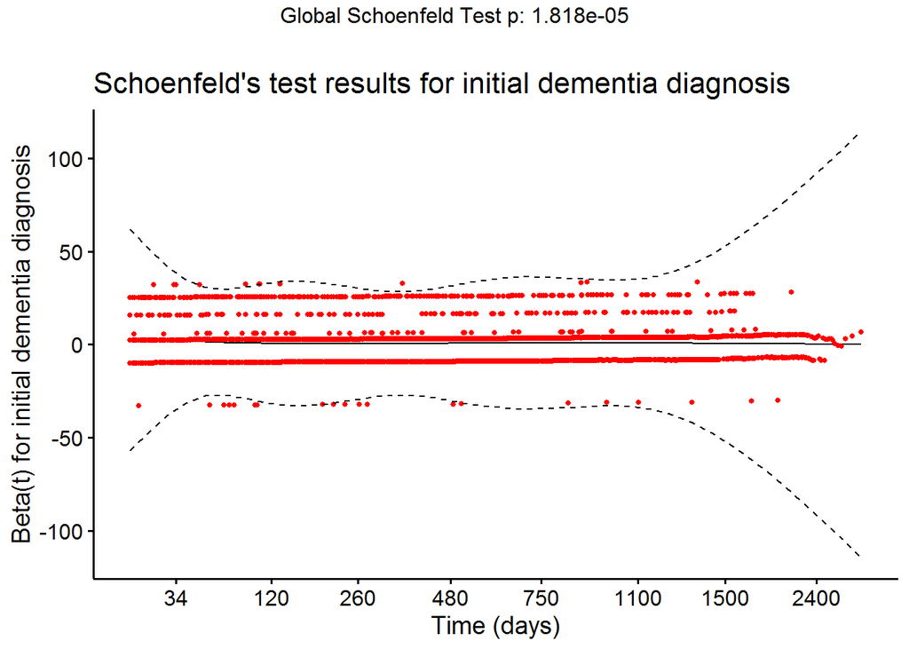

```r
res5 <- cox.zph(cox5)

plot_schoenfeld(res5, "initial dementia diagnosis")
```

```
## [1] "Survival probablity in OxNHS dementia patients: Age 65+"
## [1] "Adjusted for initial dementia diagnosis (time-dependent analysis)"
```

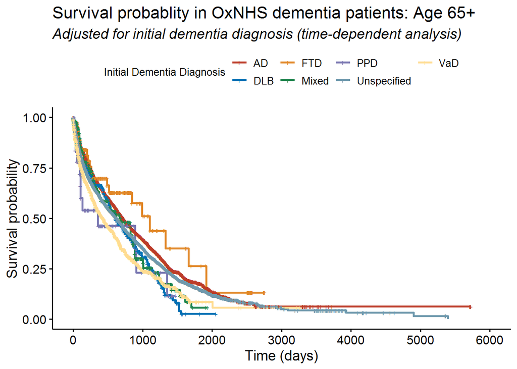

```r
fit5 <- survfit(Surv(time1, time2, event_death) ~ cause_diagper, data = all_df)

plot_surv(fit5, "initial dementia diagnosis", c("AD", "DLB", "FTD", "Mixed", "PPD", "Unspecified", "VaD"))
```

```r
anova(cox5)
```

```
## Analysis of Deviance Table
##  Cox model: response is Surv(time1, time2, event_death)
## Terms added sequentially (first to last)
##
##               loglik Chisq Df Pr(>|Chi|)
## NULL          -41451
## cause_diagper -41422 57.04  6  1.793e-10 ***
## ---
## Signif. codes:  0 '***' 0.001 '**' 0.01 '*' 0.05 '.' 0.1 ' ' 1
```

**Racial group**

```r
all_df <- all_df %>%
   mutate(Ethnicity_Value = as.factor(Ethnicity_Value)) %>%
   mutate(Ethnicity_Value = relevel(Ethnicity_Value, "White")) #use relevel for ease of interpretation

freq_per_info(all_df$Ethnicity_Value) #reminder of this category's groups
```

```
## var :
##         Frequency   %(NA+)   %(NA-)
## White       39504     69.8     97.0
## NA's        15909     28.1      0.0
## Other         478      0.8      1.2
## Asian         437      0.8      1.1
## Black         296      0.5      0.7
##   Total     56624    100.0    100.0
```

```r
cox6 <- coxph(Surv(time1, time2, event_death) ~ Ethnicity_Value, data = all_df)

summary(cox6)
```

[output not shown]

```r
cox.zph(cox6)
```

```
##                 chisq df      p
## Ethnicity_Value  13.4  3 0.0038
## GLOBAL           13.4  3 0.0038
```

```
## [1] "Schoenfeld's test results for race"
## [1] "Beta(t) for race"
```

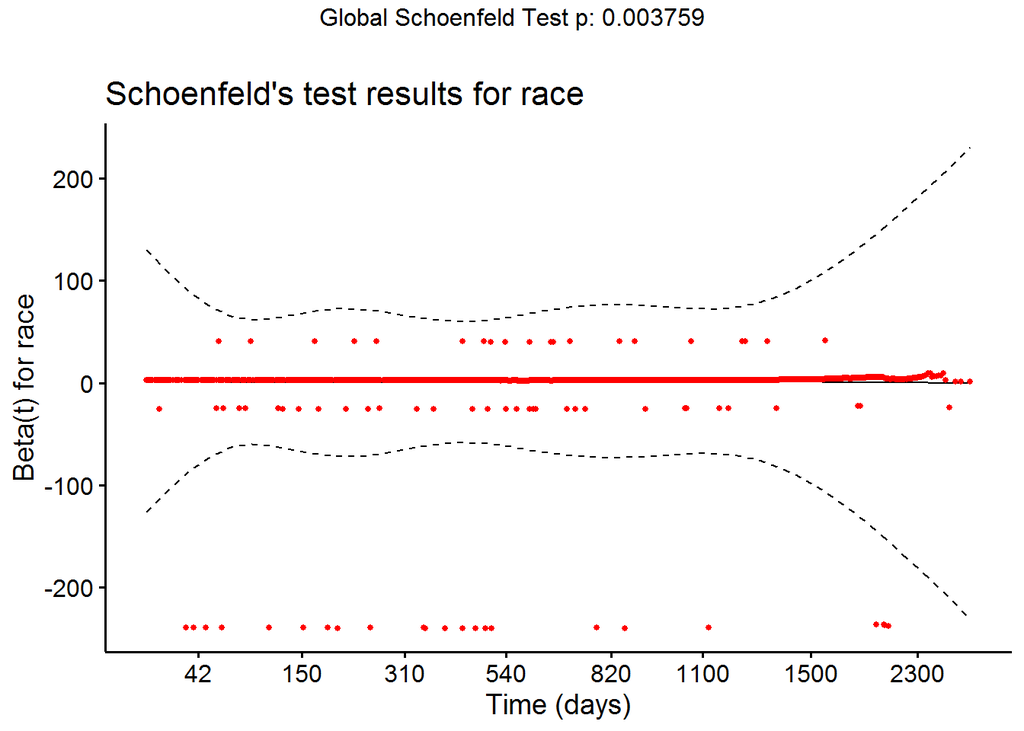

```r
res6 <- cox.zph(cox6)

plot_schoenfeld(res6, "race")
```

```
## [1] "Survival probablity in OxNHS dementia patients: Age 65+"
## [1] "Adjusted for race (time-dependent analysis)"
```

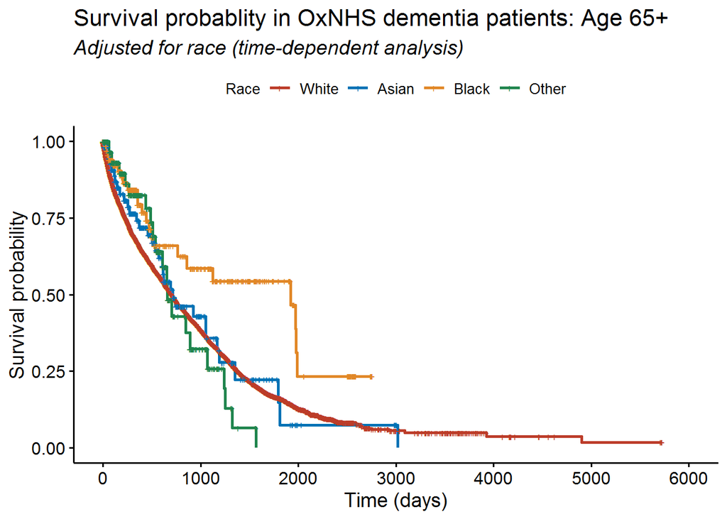

```r
fit6 <- survfit(Surv(time1, time2, event_death) ~ Ethnicity_Value, data = all_df)

plot_surv(fit6, "race", c("White", "Asian", "Black", "Other"))
```

```r
anova(cox6)
```

```
## Analysis of Deviance Table
##  Cox model: response is Surv(time1, time2, event_death)
## Terms added sequentially (first to last)
##
##                 loglik  Chisq Df Pr(>|Chi|)
## NULL            -27681
## Ethnicity_Value -27675 11.144  3    0.01097 *
## ---
## Signif. codes:  0 '***' 0.001 '**' 0.01 '*' 0.05 '.' 0.1 ' ' 1
```

**Dementia medication class**

```r
table(all_df$type_medclass) #reminder of this category's groups
```

```
##
## Any AChEi Mementine
##     33128      7463
```

```r
cox7 <- coxph(Surv(time1, time2, event_death) ~ type_medclass, data = all_df)

summary(cox7)
```

```
## Call:
## coxph(formula = Surv(time1, time2, event_death) ~ type_medclass,
##     data = all_df)
##
##   n= 40591, number of events= 3012
##    (16033 observations deleted due to missingness)
##
##                           coef exp(coef) se(coef)     z Pr(>|z|)
## type_medclassMementine 0.68089   1.97563  0.04781 14.24   <2e-16 ***
## ---
## Signif. codes:  0 '***' 0.001 '**' 0.01 '*' 0.05 '.' 0.1 ' ' 1
##
##                        exp(coef) exp(-coef) lower .95 upper .95
## type_medclassMementine     1.976     0.5062     1.799      2.17
##
## Concordance= 0.538  (se = 0.004 )
## Likelihood ratio test= 175.6  on 1 df,   p=<2e-16
## Wald test            = 202.8  on 1 df,   p=<2e-16
## Score (logrank) test = 210.6  on 1 df,   p=<2e-16
```

```r
cox.zph(cox7)
```

```
##               chisq df    p
## type_medclass  2.37  1 0.12
## GLOBAL         2.37  1 0.12
```

```
## [1] "Schoenfeld's test results for dementia medication class"
## [1] "Beta(t) for dementia medication class"
```

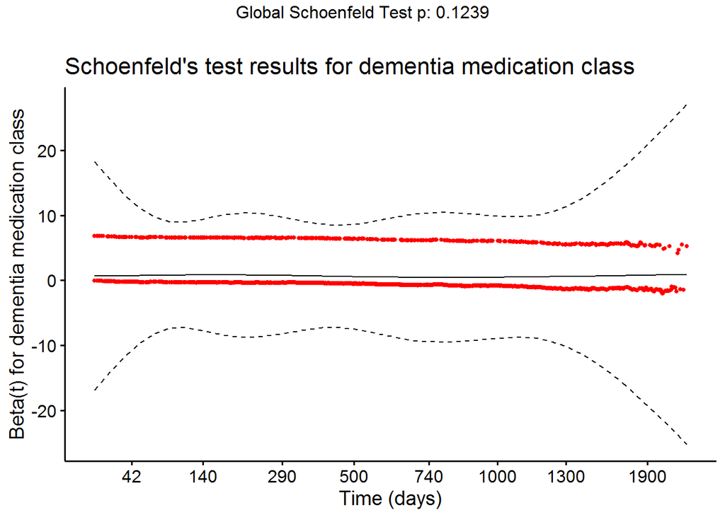

```r
res7 <- cox.zph(cox7)

plot_schoenfeld(res7, "dementia medication class")
```

```
## [1] "Survival probablity in OxNHS dementia patients: Age 65+"
## [1] "Adjusted for dementia medication class (time-dependent analysis)"
```

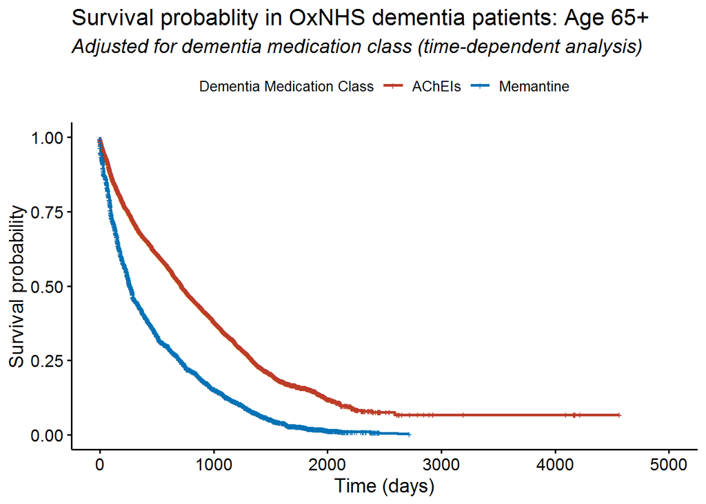

```r
fit7 <- survfit(Surv(time1, time2, event_death) ~ type_medclass, data = all_df)

plot_surv(fit7, "dementia medication class", c("AChEIs", "Memantine"))
```

```r
anova(cox7)
```

```
## Analysis of Deviance Table
##  Cox model: response is Surv(time1, time2, event_death)
## Terms added sequentially (first to last)
##
##               loglik  Chisq Df Pr(>|Chi|)
## NULL          -22703
## type_medclass -22616 175.55  1  < 2.2e-16 ***
## ---
## Signif. codes:  0 '***' 0.001 '**' 0.01 '*' 0.05 '.' 0.1 ' ' 1
```

**Marital status**

```r
freq_per_info(all_df$marital_status)
```

```
## var :
##                    Frequency   %(NA+)   %(NA-)
## <NA>                   21639     38.2      0.0
## Any union              18923     33.4     54.1
## Widowed                12253     21.6     35.0
## Single                  2089      3.7      6.0
## Divorced/Separated      1720      3.0      4.9
##   Total                56624    100.0    100.0
```

```r
cox8 <- coxph(Surv(time1, time2, event_death) ~ marital_status, data = all_df)

summary(cox8)
```

```
## Call:
## coxph(formula = Surv(time1, time2, event_death) ~ marital_status,
##     data = all_df)
##
##   n= 34985, number of events= 2838
##    (21639 observations deleted due to missingness)
##
##                                      coef exp(coef) se(coef)      z Pr(>|z|)
## marital_statusDivorced/Separated -0.25815   0.77248  0.10727 -2.407   0.0161
## marital_statusSingle              0.11710   1.12424  0.07661  1.529   0.1264
## marital_statusWidowed             0.32368   1.38221  0.03977  8.138 4.01e-16
##
## marital_statusDivorced/Separated *
## marital_statusSingle
## marital_statusWidowed            ***
## ---
## Signif. codes:  0 '***' 0.001 '**' 0.01 '*' 0.05 '.' 0.1 ' ' 1
##
##                                  exp(coef) exp(-coef) lower .95 upper .95
## marital_statusDivorced/Separated    0.7725     1.2945    0.6260    0.9532
## marital_statusSingle                1.1242     0.8895    0.9675    1.3064
## marital_statusWidowed               1.3822     0.7235    1.2786    1.4943
##
## Concordance= 0.549  (se = 0.006 )
## Likelihood ratio test= 81.48  on 3 df,   p=<2e-16
## Wald test            = 81.3  on 3 df,   p=<2e-16
## Score (logrank) test = 82.23  on 3 df,   p=<2e-16
```

```r
cox.zph(cox8)
```

```
##                chisq df     p
## marital_status  6.58  3 0.087
## GLOBAL          6.58  3 0.087
```

```
## [1] "Schoenfeld's test results for marital status"
## [1] "Beta(t) for marital status"
```

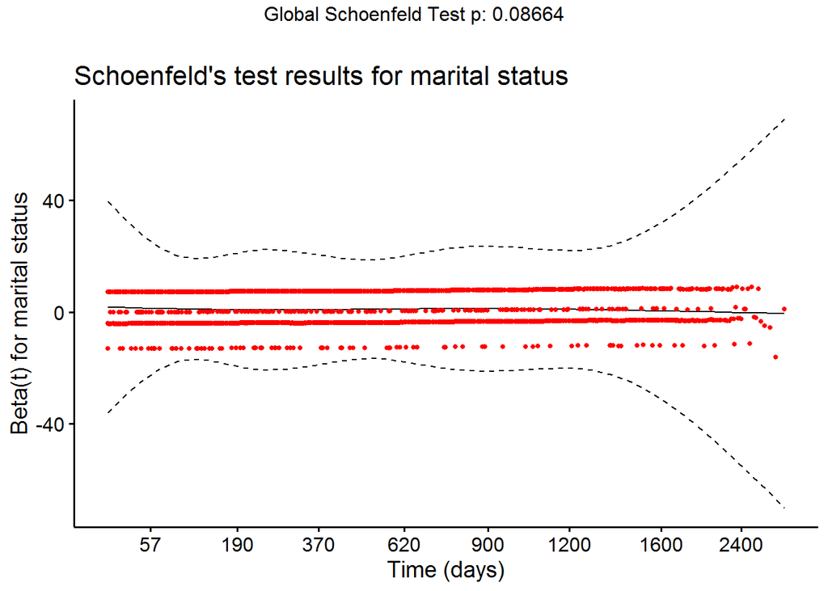

```r
res8 <- cox.zph(cox8)

plot_schoenfeld(res8, "marital status")
```

```
## [1] "Survival probablity in OxNHS dementia patients: Age 65+"
## [1] "Adjusted for marital status (time-dependent analysis)"
```

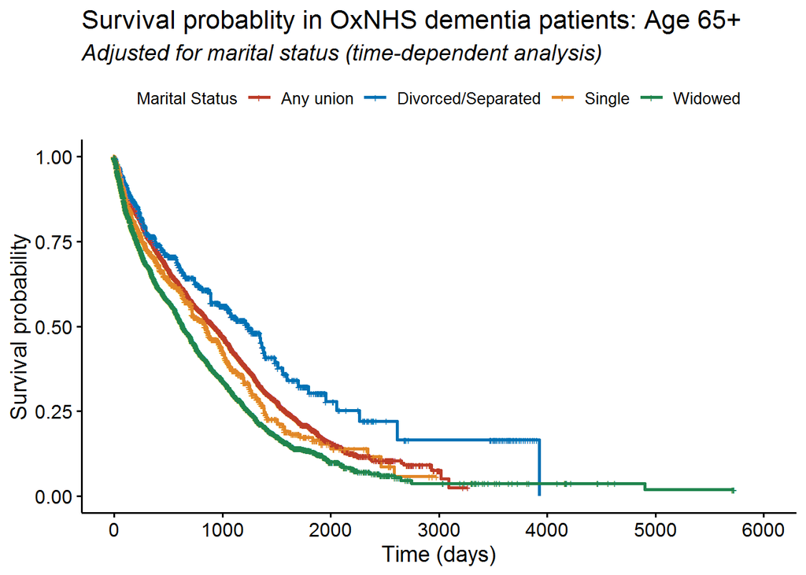

```r
fit8 <- survfit(Surv(time1, time2, event_death) ~ marital_status, data = all_df)

plot_surv(fit8, "marital status", c("Any union", "Divorced/Separated", "Single", "Widowed"))
```

```r
anova(cox8)
```

```
## Analysis of Deviance Table
##  Cox model: response is Surv(time1, time2, event_death)
## Terms added sequentially (first to last)
##
##                loglik  Chisq Df Pr(>|Chi|)
## NULL           -21476
## marital_status -21435 81.483  3  < 2.2e-16 ***
## ---
## Signif. codes:  0 '***' 0.001 '**' 0.01 '*' 0.05 '.' 0.1 ' ' 1
```

**Type of cognitive assessment**

```r
table(all_df$type_cogeval)
```

```
##
##  MMSE  MOCA
## 13575  9388
```

```r
cox9 <- coxph(Surv(time1, time2, event_death) ~ type_cogeval, data = all_df)

summary(cox9)
```

```
## Call:
## coxph(formula = Surv(time1, time2, event_death) ~ type_cogeval,
##     data = all_df)
##
##   n= 22963, number of events= 2275
##    (33661 observations deleted due to missingness)
##
##                       coef exp(coef)  se(coef)      z Pr(>|z|)
## type_cogevalMOCA -0.002258  0.997745  0.046527 -0.049    0.961
##
##                  exp(coef) exp(-coef) lower .95 upper .95
## type_cogevalMOCA    0.9977      1.002    0.9108     1.093
##
## Concordance= 0.498  (se = 0.006 )
## Likelihood ratio test= 0  on 1 df,   p=1
## Wald test            = 0  on 1 df,   p=1
## Score (logrank) test = 0  on 1 df,   p=1
```

```r
cox.zph(cox9)
```

```
##              chisq df    p
## type_cogeval 0.444  1 0.51
## GLOBAL       0.444  1 0.51
```

```
## [1] "Schoenfeld's test results for type of cognitive assessment"
## [1] "Beta(t) for type of cognitive assessment"
```

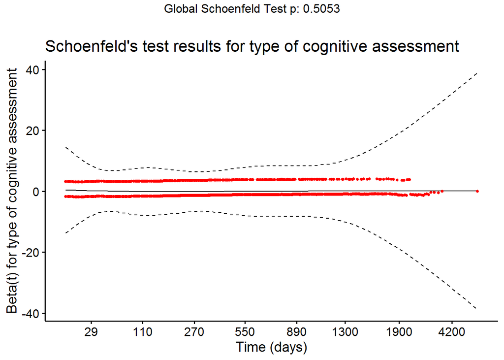

```r
res9 <- cox.zph(cox9)

plot_schoenfeld(res9, "type of cognitive assessment")
```

```
## [1] "Survival probablity in OxNHS dementia patients: Age 65+"
## [1] "Adjusted for type of cognitive assessment (time-dependent analysis)"
```

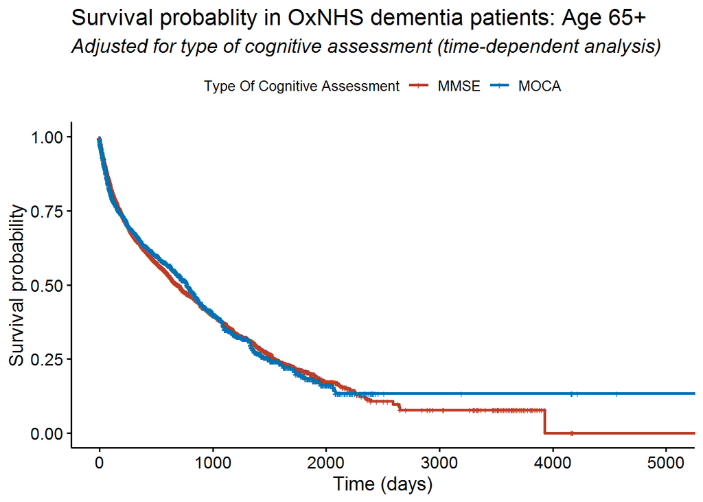

```r
fit9 <- survfit(Surv(time1, time2, event_death) ~ type_cogeval, data = all_df)

plot_surv(fit9, "type of cognitive assessment", c("MMSE", "MOCA"))
```

```r
anova(cox9)
```

```
## Analysis of Deviance Table
##  Cox model: response is Surv(time1, time2, event_death)
## Terms added sequentially (first to last)
##
##              loglik  Chisq Df Pr(>|Chi|)
## NULL         -17238
## type_cogeval -17238 0.0024  1     0.9613
```

**Score in cognitive assessment**

```r
cox10 <- coxph(Surv(time1, time2, event_death) ~ numerator, data = all_df)

summary(cox10)
```

```
## Call:
## coxph(formula = Surv(time1, time2, event_death) ~ numerator,
##     data = all_df)
##
##   n= 22963, number of events= 2275
##    (33661 observations deleted due to missingness)
##
##                coef exp(coef)  se(coef)     z Pr(>|z|)
## numerator -0.044248  0.956717  0.002818 -15.7   <2e-16 ***
## ---
## Signif. codes:  0 '***' 0.001 '**' 0.01 '*' 0.05 '.' 0.1 ' ' 1
##
##           exp(coef) exp(-coef) lower .95 upper .95
## numerator    0.9567      1.045    0.9514     0.962
##
## Concordance= 0.596  (se = 0.007 )
## Likelihood ratio test= 232.2  on 1 df,   p=<2e-16
## Wald test            = 246.6  on 1 df,   p=<2e-16
## Score (logrank) test = 250.4  on 1 df,   p=<2e-16
```

```r
cox.zph(cox10)
```

```
##           chisq df    p
## numerator   1.5  1 0.22
## GLOBAL      1.5  1 0.22
```

```
## [1] "Schoenfeld's test results for score in cognitive assessment"
## [1] "Beta(t) for score in cognitive assessment"
```

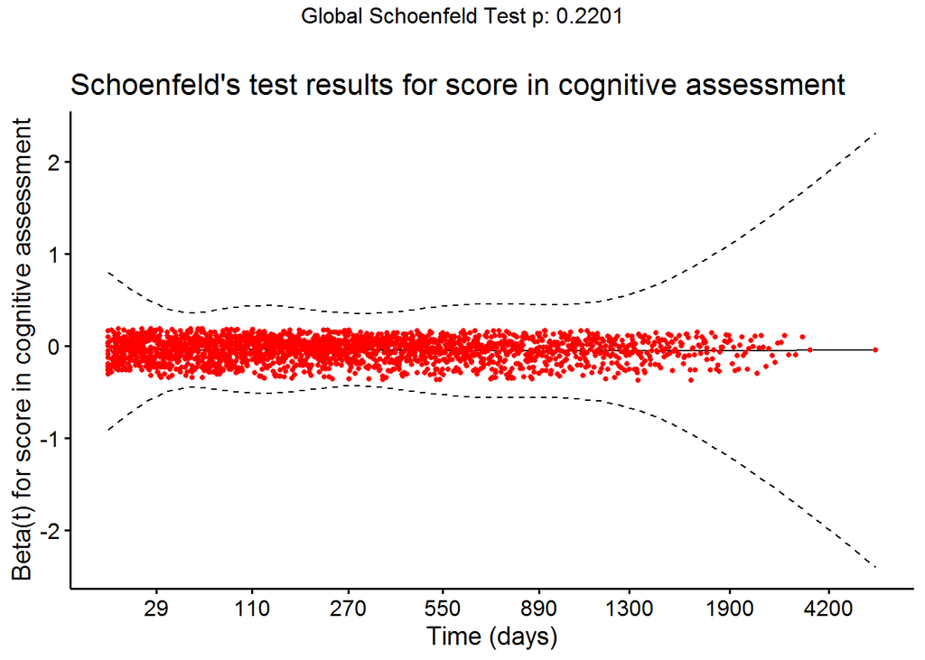

```r
res10 <- cox.zph(cox10)

plot_schoenfeld(res10, "score in cognitive assessment")
```

```r
anova(cox10)
```

```
## Analysis of Deviance Table
##  Cox model: response is Surv(time1, time2, event_death)
## Terms added sequentially (first to last)
##
##           loglik  Chisq Df Pr(>|Chi|)
## NULL      -17238
## numerator -17122 232.16  1  < 2.2e-16 ***
## ---
## Signif. codes:  0 '***' 0.001 '**' 0.01 '*' 0.05 '.' 0.1 ' ' 1
```

**Type of chronic medication**

```r
freq_per_info(all_df$medother_grouped)
```

```
## var :
##                Frequency   %(NA+)   %(NA-)
## <NA>               40436     71.4      0.0
## Antipsychotics      6071     10.7     37.5
## SSRIs               3821      6.7     23.6
## Trazodone           2956      5.2     18.3
## TeCAs               1929      3.4     11.9
## Insulin              524      0.9      3.2
## SNRIs                488      0.9      3.0
## TCAs                 399      0.7      2.5
##   Total            56624    100.0    100.0
```

```r
cox11 <- coxph(Surv(time1, time2, event_death) ~ medother_grouped, data = all_df)

summary(cox11)
```

```
## Call:
## coxph(formula = Surv(time1, time2, event_death) ~ medother_grouped,
##     data = all_df)
##
##   n= 16188, number of events= 1129
##    (40436 observations deleted due to missingness)
##
##                               coef exp(coef) se(coef)      z Pr(>|z|)
## medother_groupedInsulin   -0.37095   0.69008  0.16758 -2.214  0.02686 *
## medother_groupedSNRIs     -0.60981   0.54345  0.22041 -2.767  0.00566 **
## medother_groupedSSRIs     -0.33403   0.71603  0.07911 -4.222 2.42e-05 ***
## medother_groupedTCAs      -0.49803   0.60773  0.18549 -2.685  0.00726 **
## medother_groupedTeCAs     -0.28536   0.75174  0.10132 -2.817  0.00485 **
## medother_groupedTrazodone  0.18223   1.19989  0.08370  2.177  0.02947 *
## ---
## Signif. codes:  0 '***' 0.001 '**' 0.01 '*' 0.05 '.' 0.1 ' ' 1
##
##                           exp(coef) exp(-coef) lower .95 upper .95
## medother_groupedInsulin      0.6901     1.4491    0.4969    0.9584
## medother_groupedSNRIs        0.5435     1.8401    0.3528    0.8371
## medother_groupedSSRIs        0.7160     1.3966    0.6132    0.8361
## medother_groupedTCAs         0.6077     1.6455    0.4225    0.8742
## medother_groupedTeCAs        0.7517     1.3302    0.6163    0.9169
## medother_groupedTrazodone    1.1999     0.8334    1.0183    1.4138
##
## Concordance= 0.561  (se = 0.01 )
## Likelihood ratio test= 57.7  on 6 df,   p=1e-10
## Wald test            = 58  on 6 df,   p=1e-10
## Score (logrank) test = 59.16  on 6 df,   p=7e-11
```

```r
cox.zph(cox11)
```

```
##                  chisq df    p
## medother_grouped  7.44  6 0.28
## GLOBAL            7.44  6 0.28
```

```
## [1] "Schoenfeld's test results for type of chronic medication"
## [1] "Beta(t) for type of chronic medication"
```

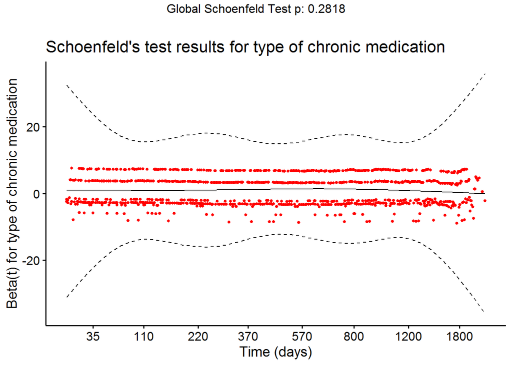

```r
res11 <- cox.zph(cox11)

plot_schoenfeld(res11, "type of chronic medication")
```

```
## [1] "Survival probablity in OxNHS dementia patients: Age 65+"
## [1] "Adjusted for type of chronic medication (time-dependent analysis)"
```

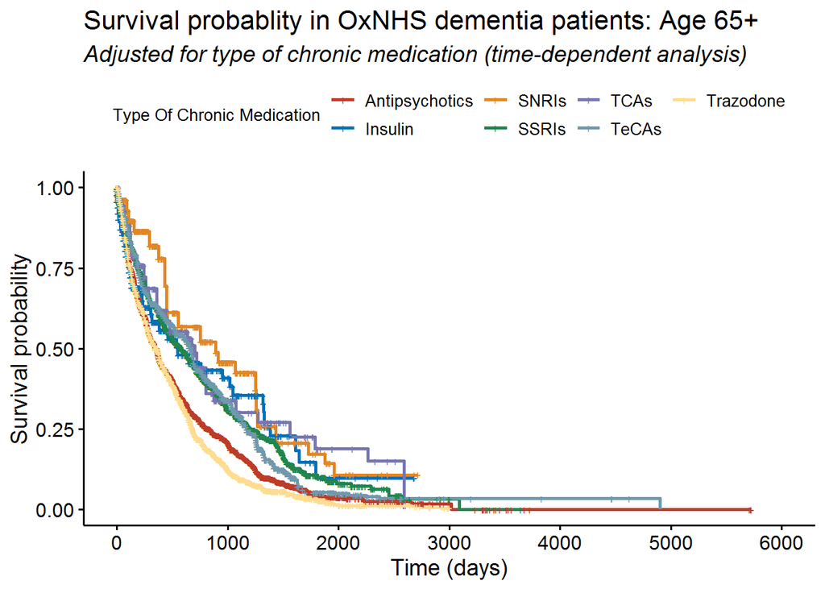

```r
fit11 <- survfit(Surv(time1, time2, event_death) ~ medother_grouped, data = all_df)

plot_surv(fit11, "type of chronic medication", c("Antipsychotics", "Insulin", "SNRIs", "SSRIs",
                                                 "TCAs", "TeCAs", "Trazodone"))
```

```r
anova(cox11)
```

```
## Analysis of Deviance Table
##  Cox model: response is Surv(time1, time2, event_death)
## Terms added sequentially (first to last)
##
##                   loglik  Chisq Df Pr(>|Chi|)
## NULL             -6923.7
## medother_grouped -6894.9 57.695  6  1.321e-10 ***
## ---
## Signif. codes:  0 '***' 0.001 '**' 0.01 '*' 0.05 '.' 0.1 ' ' 1
```

##### **Multivariate models**

**Gender and age of entry**

```r
cox_m0 <- coxph(Surv(time1, time2, event_death) ~ Gender_Value + age_entry, data = all_df) #fit model

summary(cox_m0) #print results
```

```
## Call:
## coxph(formula = Surv(time1, time2, event_death) ~ Gender_Value +
##     age_entry, data = all_df)
##
##   n= 56624, number of events= 5065
##
##                      coef exp(coef) se(coef)      z Pr(>|z|)
## Gender_ValueMale 0.201198  1.222866 0.029009  6.936 4.04e-12 ***
## age_entry        0.078897  1.082092 0.002252 35.032  < 2e-16 ***
## ---
## Signif. codes:  0 '***' 0.001 '**' 0.01 '*' 0.05 '.' 0.1 ' ' 1
##
##                  exp(coef) exp(-coef) lower .95 upper .95
## Gender_ValueMale     1.223     0.8178     1.155     1.294
## age_entry            1.082     0.9241     1.077     1.087
##
## Concordance= 0.653  (se = 0.005 )
## Likelihood ratio test= 1303  on 2 df,   p=<2e-16
## Wald test            = 1229  on 2 df,   p=<2e-16
## Score (logrank) test = 1250  on 2 df,   p=<2e-16
```

```r
cox.zph(cox_m0) #print Schoenfeld's test results
```

```
##               chisq df       p
## Gender_Value  0.143  1    0.71
## age_entry    19.116  1 1.2e-05
## GLOBAL       19.217  2 6.7e-05
```

```
## $`1`
```

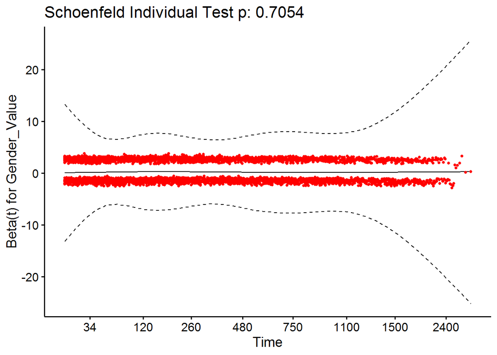

```r
resm0 <- cox.zph(cox_m0) #store Schoenfeld's test results

ggcoxzph(resm0)[1] #plot Schoenfeld's test for first variable (Gender_Value)
```

```
## $`2`
```

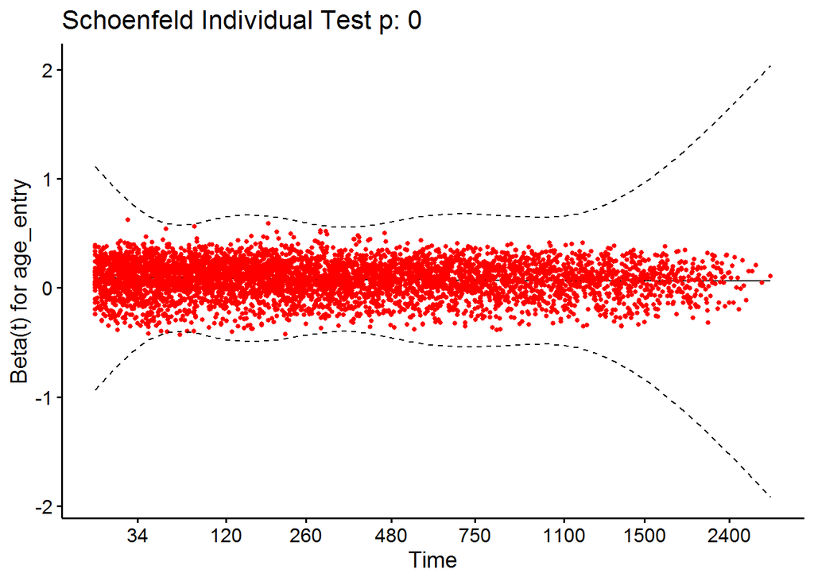

```r
ggcoxzph(resm0)[2] #plot Schoenfeld's test for second variable (age_entry)
```

```r
anova(cox_m0) #ANOVA log likelihood test to determine whether fitted model is significantly better than a no-model solution
```

```
## Analysis of Deviance Table
##  Cox model: response is Surv(time1, time2, event_death)
## Terms added sequentially (first to last)
##
##              loglik     Chisq Df Pr(>|Chi|)
## NULL         -41451
## Gender_Value -41449    2.9406  1    0.08638 .
## age_entry    -40799 1300.0638  1    < 2e-16 ***
## ---
## Signif. codes:  0 '***' 0.001 '**' 0.01 '*' 0.05 '.' 0.1 ' ' 1
```

Repeat for all other multivaraite models.

**Gender and age of observation**

```r
cox_m1 <- coxph(Surv(time1, time2, event_death) ~ Gender_Value + age_obsv, data = all_df)

summary(cox_m1)
```

```
## Call:
## coxph(formula = Surv(time1, time2, event_death) ~ Gender_Value +
##     age_obsv, data = all_df)
##
##   n= 56624, number of events= 5065
##
##                      coef exp(coef) se(coef)     z Pr(>|z|)
## Gender_ValueMale 0.210591  1.234407 0.029008  7.26 3.88e-13 ***
## age_obsv         0.084740  1.088434 0.002257 37.55  < 2e-16 ***
## ---
## Signif. codes:  0 '***' 0.001 '**' 0.01 '*' 0.05 '.' 0.1 ' ' 1
##
##                  exp(coef) exp(-coef) lower .95 upper .95
## Gender_ValueMale     1.234     0.8101     1.166     1.307
## age_obsv             1.088     0.9188     1.084     1.093
##
## Concordance= 0.657  (se = 0.005 )
## Likelihood ratio test= 1506  on 2 df,   p=<2e-16
## Wald test            = 1411  on 2 df,   p=<2e-16
## Score (logrank) test = 1438  on 2 df,   p=<2e-16
```

```r
cox.zph(cox_m1)
```

```
##               chisq df    p
## Gender_Value 0.0519  1 0.82
## age_obsv     2.3010  1 0.13
## GLOBAL       2.3010  2 0.32
```

```r
resm1 <- cox.zph(cox_m1)

ggcoxzph(resm1)[1]
```

```
## $`1`
```

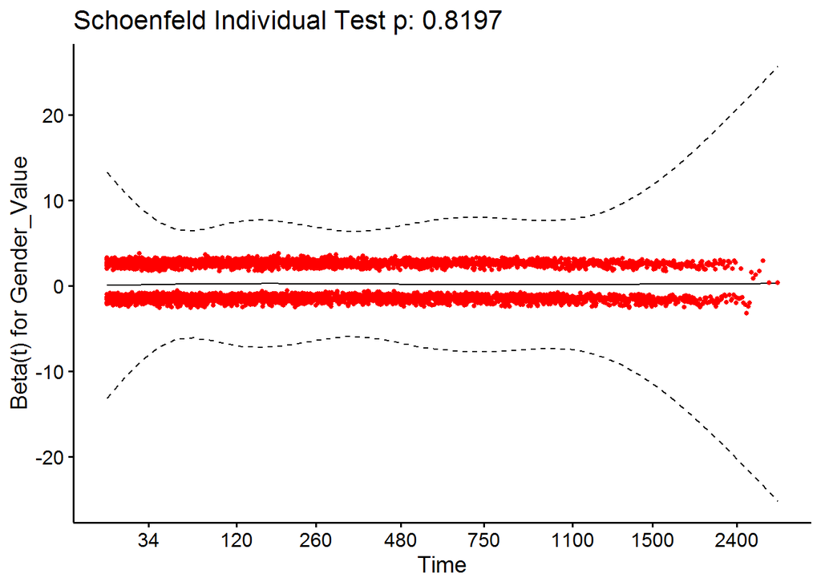

```r
ggcoxzph(resm1)[2]
```

```
## $`2`
```

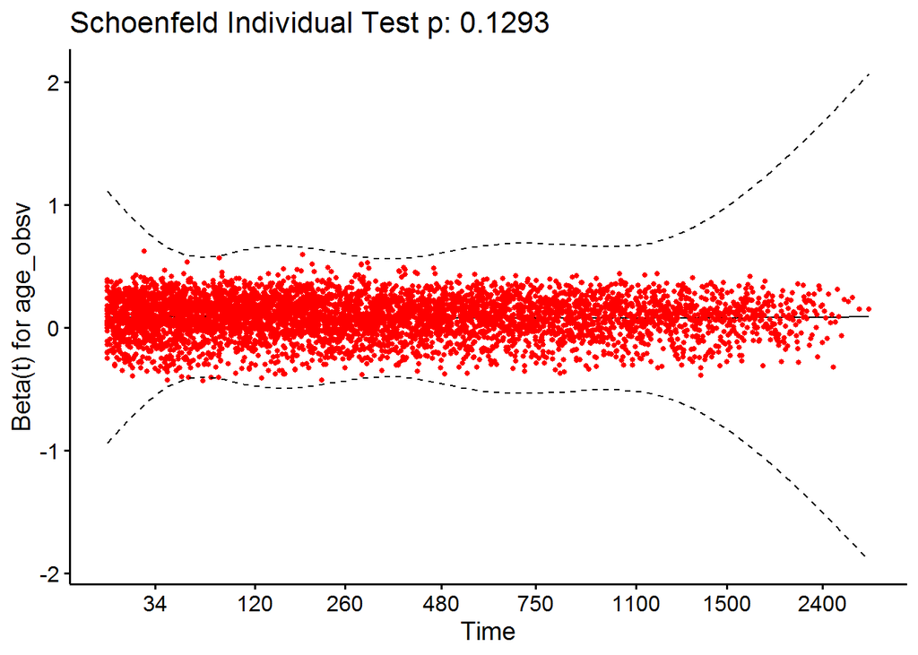

```r
anova(cox_m1)
```

```
## Analysis of Deviance Table
##  Cox model: response is Surv(time1, time2, event_death)
## Terms added sequentially (first to last)
##
##              loglik     Chisq Df Pr(>|Chi|)
## NULL         -41451
## Gender_Value -41449    2.9406  1    0.08638 .
## age_obsv     -40698 1503.4388  1    < 2e-16 ***
## ---
## Signif. codes:  0 '***' 0.001 '**' 0.01 '*' 0.05 '.' 0.1 ' ' 1
```

We plotted models’ results as forest plots for models that met the proportionality assumption and for which all covariates were significant.

*Forest plot*

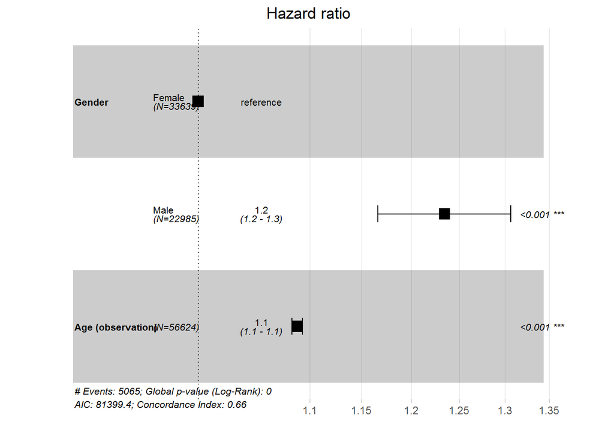

```r
#the steps below apply to all forest plots created henceforward

#subset data for forest plot's aesthetics

forest_df1 <- all_df %>%
  transmute(time1, #extract survival object terms
            time2,
            event_death,
            Gender = factor(Gender_Value), #extract covariates of interest and rename
            `Age (observation)` = age_obsv) %>%
  mutate(Gender = relevel(Gender, ref = "Female")) #relevel when necessary so hazard ratios use consistent reference groups

#fit model again, but use new variable names for aesthetics purposes

new1 <- coxph(Surv(time1, time2, event_death) ~ Gender + `Age (observation)`, data = forest_df1)

#print forest plot

ggforest(new1,
         cpositions = c(0.003, 0.17, 0.4)) #cpositions controls positions of text in plot
```

**Gender and age of diagnosis**

```r
cox_m2 <- coxph(Surv(time1, time2, event_death) ~ Gender_Value + age_diag, data = all_df)

summary(cox_m2)
```

```
## Call:
## coxph(formula = Surv(time1, time2, event_death) ~ Gender_Value +
##     age_diag, data = all_df)
##
##   n= 56624, number of events= 5065
##
##                      coef exp(coef) se(coef)      z Pr(>|z|)
## Gender_ValueMale 0.199600  1.220914 0.029032  6.875 6.19e-12 ***
## age_diag         0.073549  1.076321 0.002201 33.411  < 2e-16 ***
## ---
## Signif. codes:  0 '***' 0.001 '**' 0.01 '*' 0.05 '.' 0.1 ' ' 1
##
##                  exp(coef) exp(-coef) lower .95 upper .95
## Gender_ValueMale     1.221     0.8191     1.153     1.292
## age_diag             1.076     0.9291     1.072     1.081
##
## Concordance= 0.647  (se = 0.005 )
## Likelihood ratio test= 1178  on 2 df,   p=<2e-16
## Wald test            = 1118  on 2 df,   p=<2e-16
## Score (logrank) test = 1136  on 2 df,   p=<2e-16
```

```r
cox.zph(cox_m2)
```

```
##               chisq df       p
## Gender_Value  0.512  1    0.47
## age_diag     27.670  1 1.4e-07
## GLOBAL       27.715  2 9.6e-07
```

```r
resm2 <- cox.zph(cox_m2)

ggcoxzph(resm2)[1]
```

```
## $`1`
```

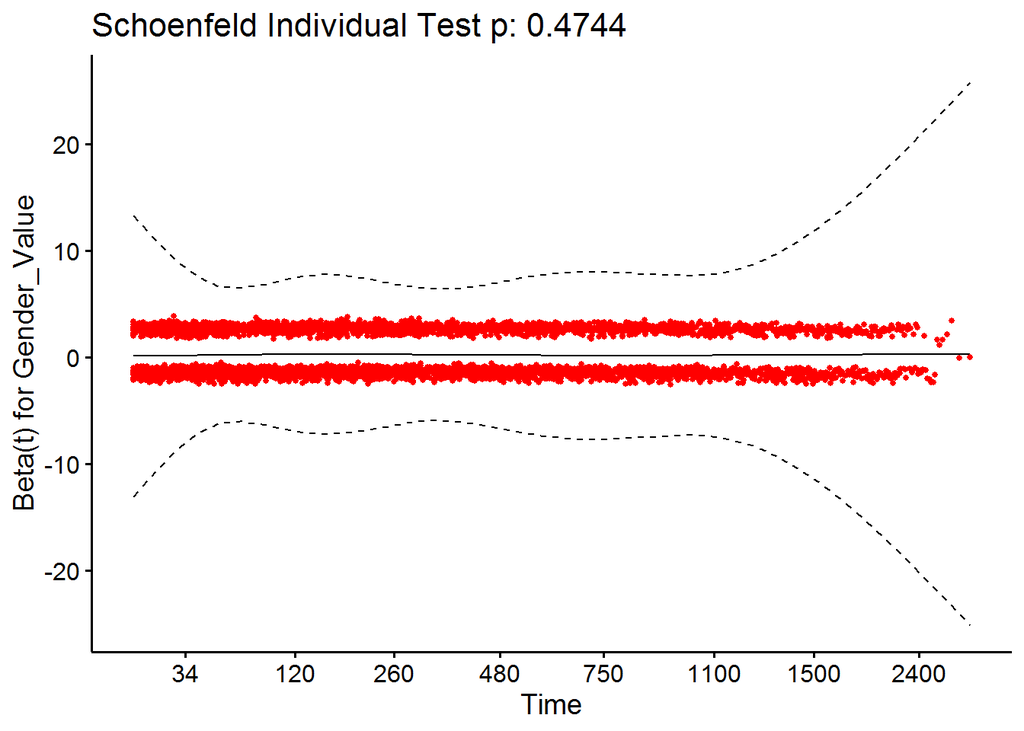

```r
ggcoxzph(resm2)[2]
```

```
## $`2`
```

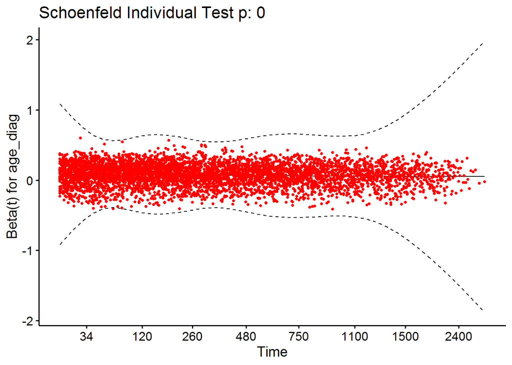

```r
anova(cox_m2)
```

```
## Analysis of Deviance Table
##  Cox model: response is Surv(time1, time2, event_death)
## Terms added sequentially (first to last)
##
##              loglik     Chisq Df Pr(>|Chi|)
## NULL         -41451
## Gender_Value -41449    2.9406  1    0.08638 .
## age_diag     -40862 1175.1009  1    < 2e-16 ***
## ---
## Signif. codes:  0 '***' 0.001 '**' 0.01 '*' 0.05 '.' 0.1 ' ' 1
```

**Gender and dementia medication exposure**

```r
cox_m3 <- coxph(Surv(time1, time2, event_death) ~ Gender_Value + med_exposure, data = all_df)

summary(cox_m3)
```

```
## Call:
## coxph(formula = Surv(time1, time2, event_death) ~ Gender_Value +
##     med_exposure, data = all_df)
##
##   n= 56624, number of events= 5065
##
##                          coef exp(coef) se(coef)     z Pr(>|z|)
## Gender_ValueMale      0.04999   1.05126  0.02863 1.746 0.080776 .
## med_exposureunexposed 0.10007   1.10525  0.02941 3.403 0.000668 ***
## ---
## Signif. codes:  0 '***' 0.001 '**' 0.01 '*' 0.05 '.' 0.1 ' ' 1
##
##                       exp(coef) exp(-coef) lower .95 upper .95
## Gender_ValueMale          1.051     0.9512    0.9939     1.112
## med_exposureunexposed     1.105     0.9048    1.0433     1.171
##
## Concordance= 0.54  (se = 0.005 )
## Likelihood ratio test= 14.41  on 2 df,   p=7e-04
## Wald test            = 14.53  on 2 df,   p=7e-04
## Score (logrank) test = 14.53  on 2 df,   p=7e-04
```

```r
cox.zph(cox_m3)
```

```
##                chisq df      p
## Gender_Value   0.357  1   0.55
## med_exposure 171.164  1 <2e-16
## GLOBAL       171.529  2 <2e-16
```

```r
resm3 <- cox.zph(cox_m3)

ggcoxzph(resm3)[1]
```

```
## $`1`
```

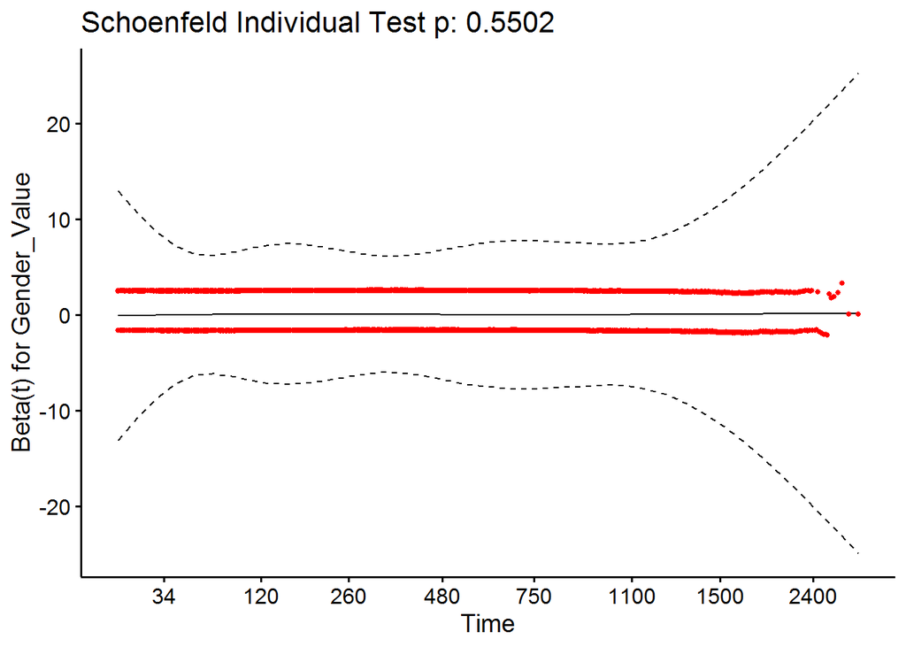

```r
ggcoxzph(resm3)[2]
```

```
## $`2`
```

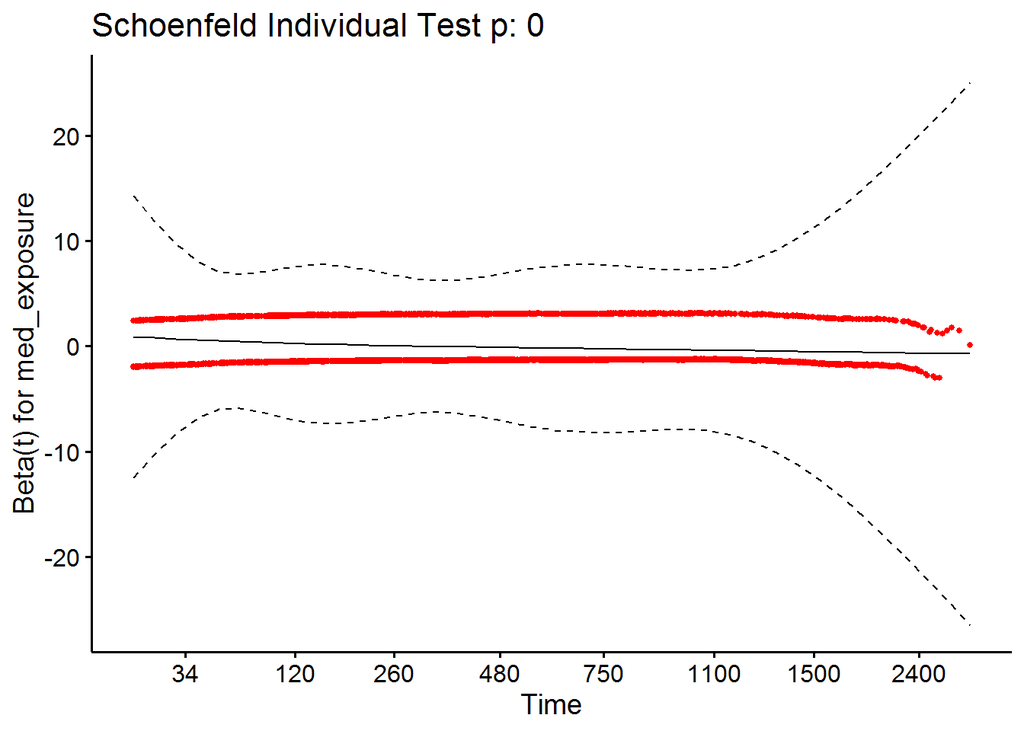

```r
anova(cox_m3)
```

```
## Analysis of Deviance Table
##  Cox model: response is Surv(time1, time2, event_death)
## Terms added sequentially (first to last)
##
##              loglik   Chisq Df Pr(>|Chi|)
## NULL         -41451
## Gender_Value -41449  2.9406  1  0.0863775 .
## med_exposure -41444 11.4680  1  0.0007081 ***
## ---
## Signif. codes:  0 '***' 0.001 '**' 0.01 '*' 0.05 '.' 0.1 ' ' 1
```

**Gender and initial diagnosis**

```r
cox_m4 <- coxph(Surv(time1, time2, event_death) ~ Gender_Value + cause_diagper, data = all_df)

summary(cox_m4)
```

```
## Call:
## coxph(formula = Surv(time1, time2, event_death) ~ Gender_Value +
##     cause_diagper, data = all_df)
##
##   n= 56624, number of events= 5065
##
##                              coef exp(coef) se(coef)      z Pr(>|z|)
## Gender_ValueMale          0.04241   1.04332  0.02867  1.479  0.13902
## cause_diagperDLB          0.29065   1.33730  0.09594  3.029  0.00245 **
## cause_diagperFTD         -0.26494   0.76725  0.22505 -1.177  0.23908
## cause_diagperMixedADVaD   0.17331   1.18924  0.13847  1.252  0.21071
## cause_diagperPPD          0.49212   1.63578  0.28984  1.698  0.08953 .
## cause_diagperUnspecified  0.13995   1.15022  0.03122  4.483 7.35e-06 ***
## cause_diagperVaD          0.40408   1.49793  0.06102  6.622 3.53e-11 ***
## ---
## Signif. codes:  0 '***' 0.001 '**' 0.01 '*' 0.05 '.' 0.1 ' ' 1
##
##                          exp(coef) exp(-coef) lower .95 upper .95
## Gender_ValueMale            1.0433     0.9585    0.9863     1.104
## cause_diagperDLB            1.3373     0.7478    1.1081     1.614
## cause_diagperFTD            0.7673     1.3034    0.4936     1.193
## cause_diagperMixedADVaD     1.1892     0.8409    0.9066     1.560
## cause_diagperPPD            1.6358     0.6113    0.9269     2.887
## cause_diagperUnspecified    1.1502     0.8694    1.0820     1.223
## cause_diagperVaD            1.4979     0.6676    1.3291     1.688
##
## Concordance= 0.533  (se = 0.005 )
## Likelihood ratio test= 59.22  on 7 df,   p=2e-10
## Wald test            = 60.92  on 7 df,   p=1e-10
## Score (logrank) test = 61.37  on 7 df,   p=8e-11
```

```r
cox.zph(cox_m4)
```

```
##                chisq df       p
## Gender_Value   0.379  1    0.54
## cause_diagper 31.755  6 1.8e-05
## GLOBAL        32.090  7 3.9e-05
```

```r
resm4 <- cox.zph(cox_m4)

ggcoxzph(resm4)[1]
```

```
## $`1`
```

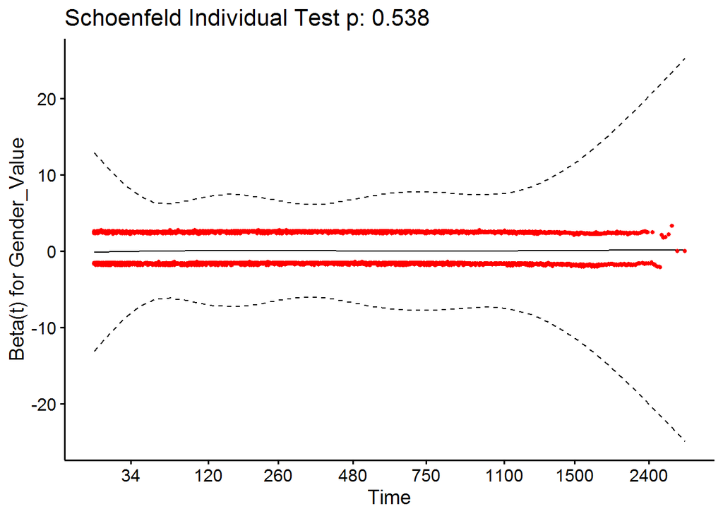

```r
ggcoxzph(resm4)[2]
```

```
## $`2`
```

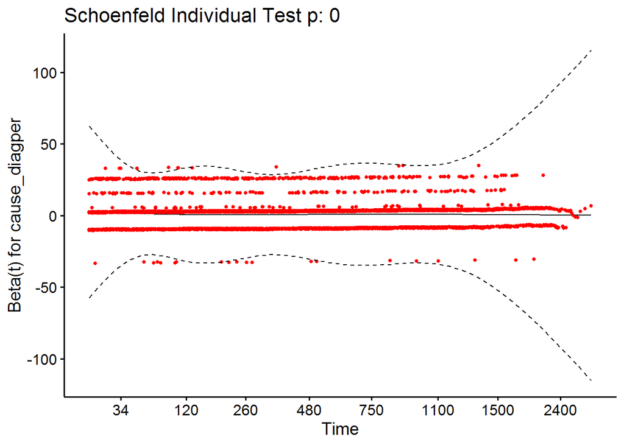

```r
anova(cox_m4)
```

```
## Analysis of Deviance Table
##  Cox model: response is Surv(time1, time2, event_death)
## Terms added sequentially (first to last)
##
##               loglik   Chisq Df Pr(>|Chi|)
## NULL          -41451
## Gender_Value  -41449  2.9406  1    0.08638 .
## cause_diagper -41421 56.2820  6  2.553e-10 ***
## ---
## Signif. codes:  0 '***' 0.001 '**' 0.01 '*' 0.05 '.' 0.1 ' ' 1
```

**Gender, age at observation, and age of entry**

```r
cox_m5 <- coxph(Surv(time1, time2, event_death) ~ Gender_Value + age_obsv + age_entry, data = all_df)

summary(cox_m5)
```

```
## Call:
## coxph(formula = Surv(time1, time2, event_death) ~ Gender_Value +
##     age_obsv + age_entry, data = all_df)
##
##   n= 56624, number of events= 5065
##
##                      coef exp(coef) se(coef)       z Pr(>|z|)
## Gender_ValueMale  0.18374   1.20170  0.02904   6.328 2.48e-10 ***
## age_obsv          0.98412   2.67544  0.03723  26.436  < 2e-16 ***
## age_entry        -0.90495   0.40456  0.03727 -24.278  < 2e-16 ***
## ---
## Signif. codes:  0 '***' 0.001 '**' 0.01 '*' 0.05 '.' 0.1 ' ' 1
##
##                  exp(coef) exp(-coef) lower .95 upper .95
## Gender_ValueMale    1.2017     0.8322    1.1352    1.2721
## age_obsv            2.6754     0.3738    2.4872    2.8779
## age_entry           0.4046     2.4718    0.3761    0.4352
##
## Concordance= 0.681  (se = 0.004 )
## Likelihood ratio test= 2361  on 3 df,   p=<2e-16
## Wald test            = 1909  on 3 df,   p=<2e-16
## Score (logrank) test = 2003  on 3 df,   p=<2e-16
```

```r
cox.zph(cox_m5)
```

```
##                chisq df       p
## Gender_Value   0.242  1  0.6224
## age_obsv      20.932  1 4.8e-06
## age_entry     15.093  1  0.0001
## GLOBAL       272.204  3 < 2e-16
```

```r
resm5 <- cox.zph(cox_m5)

ggcoxzph(resm5)[1]
```

```
## $`1`
```

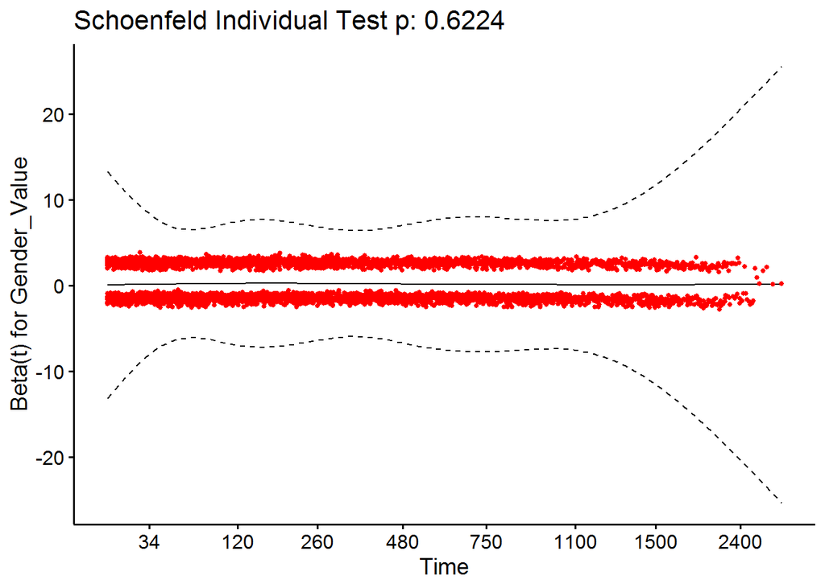